# Airport Growth Potential

Eric Hestekin

2/27/2020

Repo: https://github.com/ehestekin/MSBA_5210_DataVis

# 1 Data Load and Wrangle

Data source : [US domestic flights from 1990 to 2009, US Census Bureau](http://academictorrents.com/details/a2ccf94bbb4af222bf8e69dad60a68a29f310d9a)

```r
#Load Data TSV
#no column headers so set array of names
col_labels = c('origin_code',
               'dest_code',
               'origin_city',
               'dest_city',
               'passengers',
               'seats',
               'num_flights',
               'distance',
               'year_month',
               'origin_pop',
               'dest_pop')

#suppress colum spec message.  (Markdown code block setting doesn't work)
flights_df <- suppressMessages(read_tsv('flight_edges.tsv',col_names = col_labels))
```

Goal is to identify airports with growth potential + Answer the business question “Which airports should be targets for expansion?” + What airport and city characteristics are good predictors of flight growth?

## 1.1 First look at data

```r
head(flights_df)
```

```
## # A tibble: 6 x 11
##   origin_code dest_code origin_city dest_city passengers seats num_flights
##   <chr>       <chr>     <chr>       <chr>          <dbl> <dbl>       <dbl>
## 1 MHK         AMW       Manhattan,~ Ames, IA          21    30           1
## 2 EUG         RDM       Eugene, OR  Bend, OR          41   396          22
## 3 EUG         RDM       Eugene, OR  Bend, OR          88   342          19
## 4 EUG         RDM       Eugene, OR  Bend, OR          11    72           4
## 5 MFR         RDM       Medford, OR Bend, OR           0    18           1
## 6 MFR         RDM       Medford, OR Bend, OR          11    18           1
## # ... with 4 more variables: distance <dbl>, year_month <dbl>,
## #   origin_pop <dbl>, dest_pop <dbl>
```

```r
summary(flights_df)
```

```
##  origin_code         dest_code         origin_city
##  Length:3606803     Length:3606803     Length:3606803
##  Class :character   Class :character   Class :character
##  Mode  :character   Mode  :character   Mode  :character
##
##
##
##   dest_city           passengers        seats         num_flights
##  Length:3606803     Min.   :    0   Min.   :     0   Min.   :   0.00
##  Class :character   1st Qu.:  109   1st Qu.:   156   1st Qu.:   2.00
##  Mode  :character   Median : 1118   Median :  1998   Median :  25.00
##                     Mean   : 2689   Mean   :  4048   Mean   :  37.23
##                     3rd Qu.: 3503   3rd Qu.:  5370   3rd Qu.:  55.00
##                     Max.   :89597   Max.   :147062   Max.   :1128.00
##     distance        year_month       origin_pop          dest_pop
##  Min.   :   0.0   Min.   :199001   Min.   :   13005   Min.   :   12887
##  1st Qu.: 273.0   1st Qu.:199603   1st Qu.: 1030597   1st Qu.: 1025470
##  Median : 519.0   Median :200111   Median : 2400193   Median : 2400193
##  Mean   : 697.3   Mean   :200063   Mean   : 5871502   Mean   : 5897982
##  3rd Qu.: 927.0   3rd Qu.:200601   3rd Qu.: 8613622   3rd Qu.: 8635706
##  Max.   :5095.0   Max.   :200912   Max.   :38139592   Max.   :38139592
```

## 1.2 Wrangle

```r
#separate month_year
#first 4 chars are year, convert from string to num
flights_df <- flights_df %>%
  separate(year_month, into = c('year','month'), sep = 4, convert = TRUE)

#add percentage of seats filled for each flight
#and remove rows where seats are zero (no flight data)
# and also remove flights where seat/flight < 4 (non commercial flight)
com_flights_df <- flights_df %>%
  mutate(load_factor = (passengers/seats) * 100) %>%
  filter(seats != 0) %>%
  filter(passengers != 0) %>%
  filter(seats/num_flights > 4) %>%
  #focus on routes offering >500 seats/wk (2150/month)
  #way too many routes with a very small number of people flying
  filter(seats > 2150)

#also throw out seat filled percentages > 100
#this shouldn't be possible so don't trust data point
com_flights_df <- filter(com_flights_df, load_factor <= 100)

#focusing on current growth prospects so only keep previous 5 years of data
com_flights_df <- com_flights_df %>%
  filter(year > (max(year) - 5))

#calculate population increase year to year
pop_increases <- com_flights_df %>%
  group_by(origin_city, year) %>%
  summarize(avg_pop = mean(origin_pop)) %>%
  arrange(desc(year), .by_group = TRUE) %>%
  mutate(pop_increase = avg_pop - lead(avg_pop))

#calculate route seats flown and offered increase year to year
flight_increases <- com_flights_df %>%
  group_by(origin_code, dest_code, year) %>%
  summarize(yrly_passenger = sum(passengers), yrly_seats = sum(seats)) %>%
  arrange(desc(year), .by_group = TRUE) %>%
  mutate(pass_growth = yrly_passenger - lead(yrly_passenger), seat_growth = yrly_seats - lead(yrly_seats),
         yrly_load_factor = yrly_passenger / yrly_seats * 100, load_factor_growth = yrly_load_factor - lead(yrly_load_factor))

#put yrly data together
#first add full city names
#then add population numbers
yrly_com_flights_df <- inner_join(flight_increases, distinct(select(com_flights_df, origin_code, origin_city)), by = 'origin_code') %>%
  inner_join(distinct(select(com_flights_df, dest_code, dest_city)), by = 'dest_code') %>%
  inner_join(pop_increases, by = c('year', 'origin_city')) %>%
  #rename columns for origin city so able to add destination population data
  rename(origin_pop = avg_pop, origin_pop_increase = pop_increase) %>%
  inner_join(rename(pop_increases, dest_city = origin_city, dest_pop = avg_pop, dest_pop_increase = pop_increase), by = c('year', 'dest_city')) %>%
  #distance got dropped during grouping
  inner_join(distinct(select(com_flights_df, origin_code, dest_code, distance)), by = c('origin_code', 'dest_code'))

#noticed there are duplicates of some rows (everything is same except distance is one mile different)
yrly_com_flights_df_no_dup_test <-  yrly_com_flights_df %>% distinct(origin_code, dest_code, year, .keep_all = TRUE)

#noticed the duplicates with the CLT/ABE route in the Individual Route and City Analysis section
#check dupes were removed
yrly_com_flights_df_no_dup_test %>% filter(origin_code == 'CLT')
```

```
## # A tibble: 436 x 16
## # Groups:   origin_code, dest_code [94]
##    origin_code dest_code  year yrly_passenger yrly_seats pass_growth
##    <chr>       <chr>     <int>          <dbl>      <dbl>       <dbl>
##  1 CLT         ABE        2009          31559      44687      -26621
##  2 CLT         ABE        2008          58180      77430        5485
##  3 CLT         ABE        2007          52695      71832       17216
##  4 CLT         ABE        2006          35479      56276        9011
##  5 CLT         ABE        2005          26468      49362          NA
##  6 CLT         AGS        2009          56858      82039       -2342
##  7 CLT         AGS        2008          59200      85875       13097
##  8 CLT         AGS        2007          46103      71959       12767
##  9 CLT         AGS        2006          33336      69362       -4366
## 10 CLT         AGS        2005          37702      74956          NA
## # ... with 426 more rows, and 10 more variables: seat_growth <dbl>,
## #   yrly_load_factor <dbl>, load_factor_growth <dbl>, origin_city <chr>,
## #   dest_city <chr>, origin_pop <dbl>, origin_pop_increase <dbl>,
## #   dest_pop <dbl>, dest_pop_increase <dbl>, distance <dbl>
```

```r
#looks like it worked so save df
yrly_com_flights_df <- yrly_com_flights_df_no_dup_test
rm(yrly_com_flights_df_no_dup_test)

# Save df for use in PowerBI Dash
write_csv(yrly_com_flights_df, path = 'yrly_com_flights_df.csv')


#get summary now with tidy commercial flights data set
summary(yrly_com_flights_df)
```

```
##  origin_code         dest_code              year      yrly_passenger
##  Length:20258       Length:20258       Min.   :2005   Min.   :     30
##  Class :character   Class :character   1st Qu.:2006   1st Qu.:  29242
##  Mode  :character   Mode  :character   Median :2007   Median :  63948
##                                        Mean   :2007   Mean   : 127666
##                                        3rd Qu.:2008   3rd Qu.: 150891
##                                        Max.   :2009   Max.   :1472348
##
##    yrly_seats       pass_growth       seat_growth      yrly_load_factor
##  Min.   :   2151   Min.   :-248097   Min.   :-296851   Min.   : 0.1987
##  1st Qu.:  42106   1st Qu.: -10892   1st Qu.: -16124   1st Qu.:66.5631
##  Median :  87652   Median :  -1466   Median :  -2432   Median :74.6429
##  Mean   : 169285   Mean   :  -2730   Mean   :  -5713   Mean   :72.9764
##  3rd Qu.: 197619   3rd Qu.:   5403   3rd Qu.:   5854   3rd Qu.:81.5473
##  Max.   :2024088   Max.   : 301321   Max.   : 431547   Max.   :97.1765
##                    NA's   :4797      NA's   :4797
##  load_factor_growth origin_city         dest_city
##  Min.   :-37.191    Length:20258       Length:20258
##  1st Qu.: -2.346    Class :character   Class :character
##  Median :  0.743    Mode  :character   Mode  :character
##  Mean   :  0.962
##  3rd Qu.:  3.969
##  Max.   : 50.262
##  NA's   :4797
##    origin_pop       origin_pop_increase    dest_pop
##  Min.   :   13005   Min.   :-325925     Min.   :   13005
##  1st Qu.:  975476   1st Qu.:   4829     1st Qu.:  987535
##  Median : 2102422   Median :  25604     Median : 2102422
##  Mean   : 5589402   Mean   :  50720     Mean   : 5596146
##  3rd Qu.: 6815696   3rd Qu.:  73550     3rd Qu.: 6815696
##  Max.   :38139592   Max.   : 366008     Max.   :38139592
##                     NA's   :4140
##  dest_pop_increase    distance
##  Min.   :-325925   Min.   :   0.0
##  1st Qu.:   4829   1st Qu.: 329.0
##  Median :  25604   Median : 599.0
##  Mean   :  50698   Mean   : 800.7
##  3rd Qu.:  73550   3rd Qu.:1040.0
##  Max.   : 366008   Max.   :4962.0
##  NA's   :4139
```

*Notes*

- Would be useful to look at averages for passengers and seats on a single route
- Interesting distribution of distances
  - Looks like many short routes (median << mean)
- Population skewed towards very large cities (due to more flight routes?)
- Fairly symmetrical load factor
- NAs result from not having previous data
  - New route or first year in data (2005)
- Populations are growing but distribution is skewed (mean>>median)

**Assuming very minimal net one-way travelers so origin/destination numbers are symmetric** + Focus on departing flights (origin city sorting) and assume numbers are nearly identical for arrivals

```r
# Quick check above assumption with Chicago (busiest airport by passenger volume, found below)
yrly_com_flights_df %>% filter(origin_code == 'ORD') %>%
  group_by(year) %>%
  summarize(total_departs = sum(yrly_passenger)) / #divide the arrives by departs

yrly_com_flights_df %>% filter(dest_code == 'ORD') %>%
  group_by(year) %>%
  summarize(total_arrives = sum(yrly_passenger))
```

```
##   year total_departs
## 1    1      1.002237
## 2    1      1.004571
## 3    1      1.002164
## 4    1      1.001343
## 5    1      1.000204
```

# 2 Graphical Analysis

## 2.1 How has data changed over time covered in dataset?

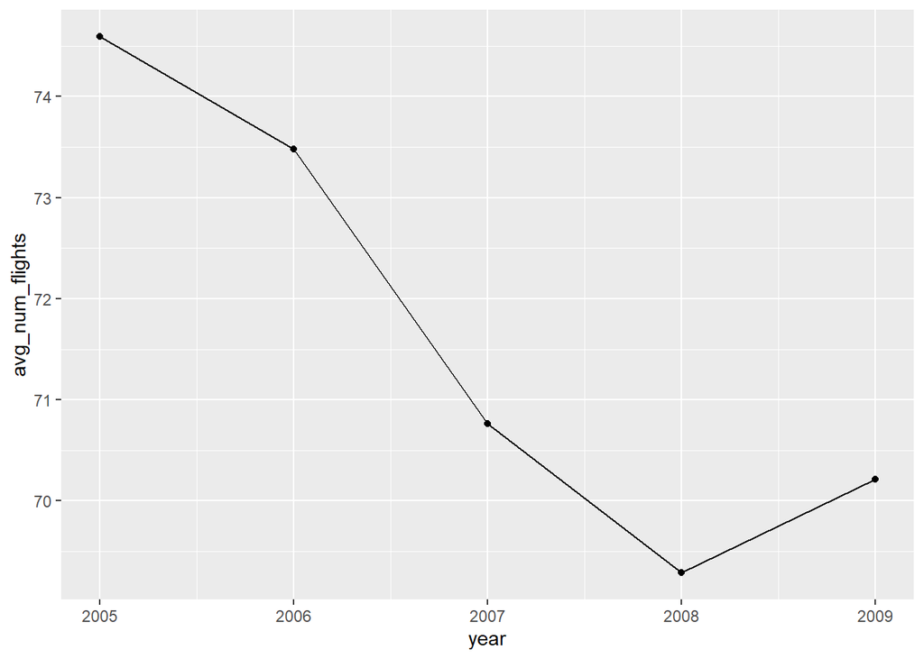

```r
com_flights_df %>%
  group_by(year) %>%
  summarise(avg_num_flights = mean(num_flights)) %>%
  ggplot(mapping = aes(x = year, y = avg_num_flights)) +
  geom_line() +
  geom_point()
```

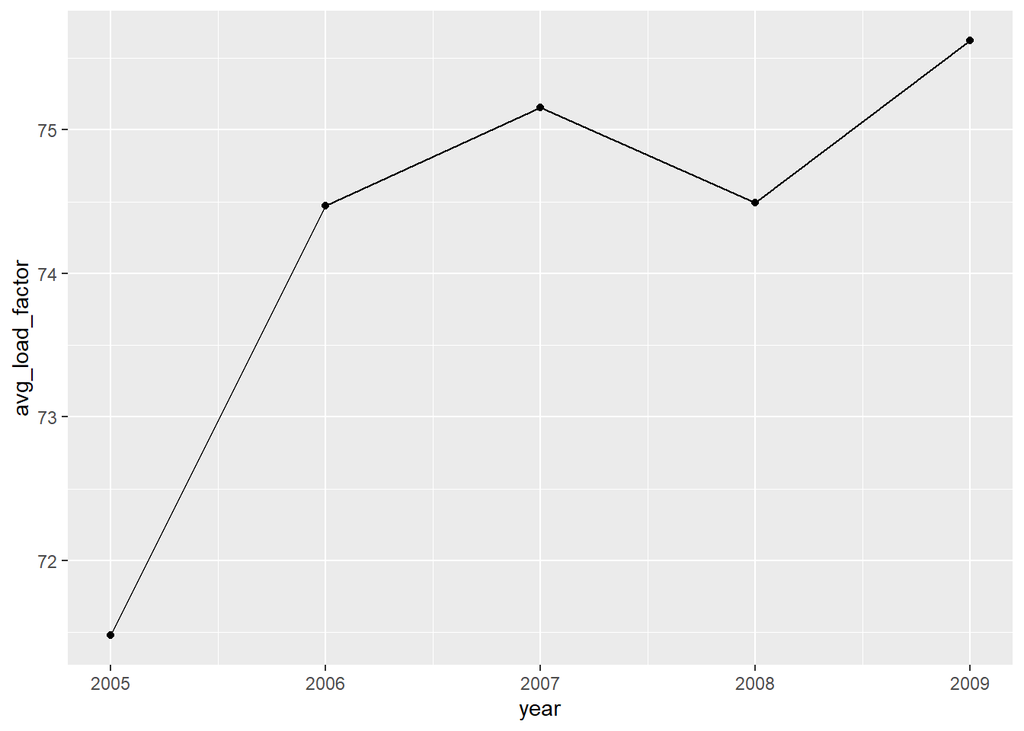

```r
com_flights_df %>%
  group_by(year) %>%
  summarise(avg_load_factor = mean(load_factor)) %>%
  ggplot(mapping = aes(x = year, y = avg_load_factor)) +
  geom_line() +
  geom_point()
```

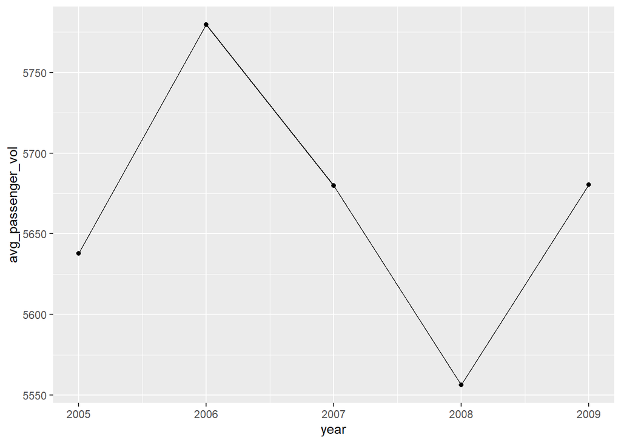

```r
com_flights_df %>%
  group_by(year) %>%
  summarise(avg_passenger_vol = mean(passengers)) %>%
  ggplot(mapping = aes(x = year, y = avg_passenger_vol)) +
  geom_line() +
  geom_point()
```

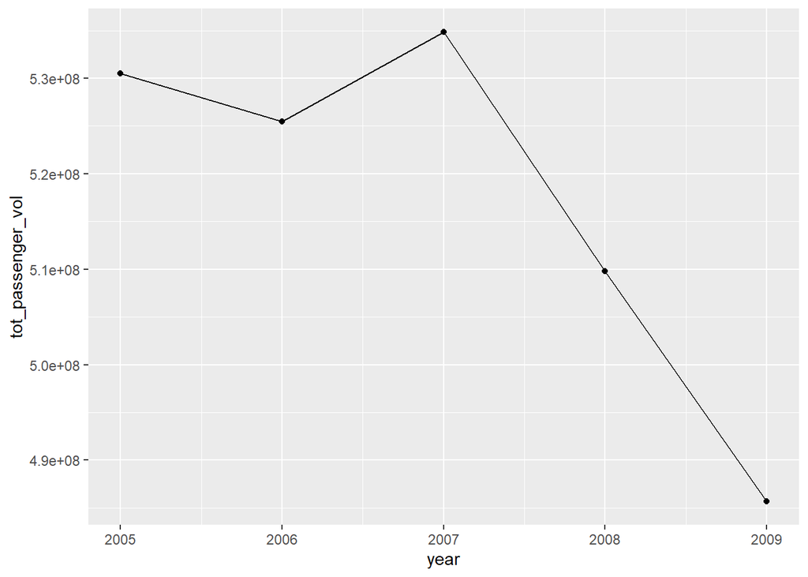

```r
com_flights_df %>%
  group_by(year) %>%
  summarise(tot_passenger_vol = sum(passengers)) %>%
  ggplot(mapping = aes(x = year, y = tot_passenger_vol)) +
  geom_line() +
  geom_point()
```

- Drop in passenger volumes from 2007 - 2009
- Increase in percentage of seats filled in same time period

## 2.2 Look at individual variables

### 2.2.1 Distance

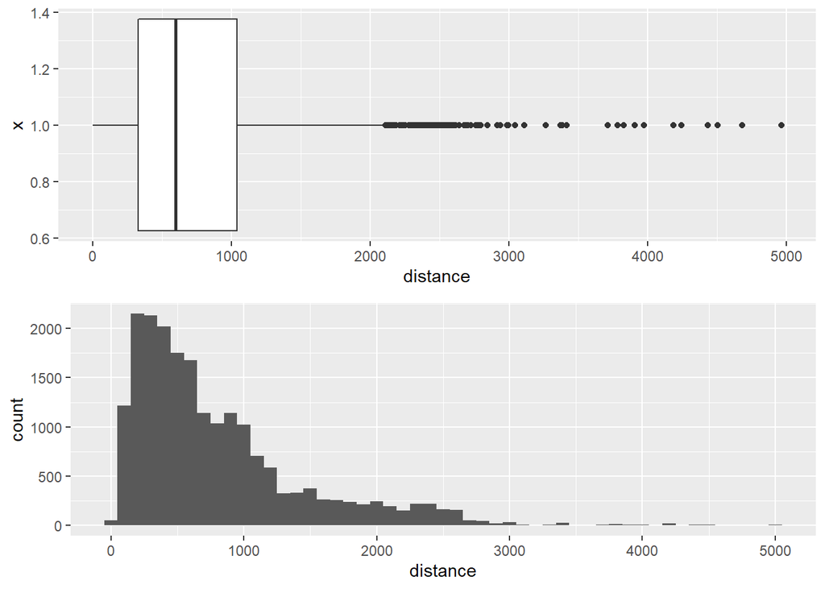

```r
grid.arrange(
  ggplot(data = yrly_com_flights_df, mapping = aes(x = 1, y = distance)) +
    geom_boxplot() +
    coord_flip(),
  #100 mile bins for easier increments
  ggplot(data = yrly_com_flights_df, mapping = aes(x = distance)) +
    geom_histogram(binwidth = 100),

  ncol = 1
)
```

- Domestic flights mostly are between 300 - 1000 miles

### 2.2.2 Load Factor

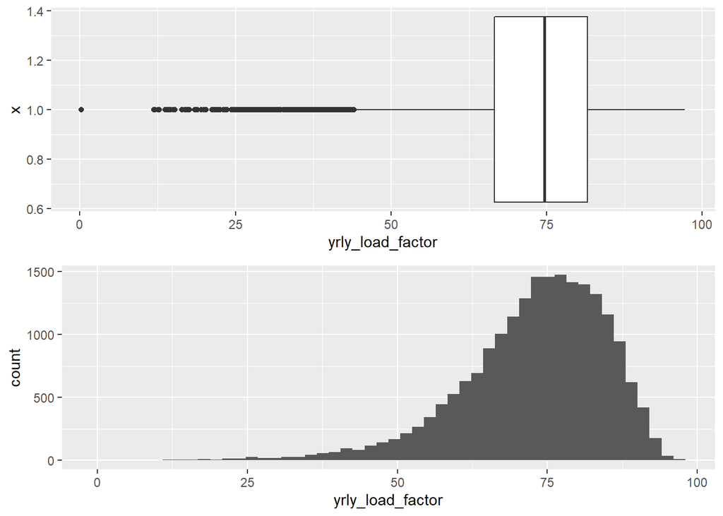

```r
grid.arrange(
  ggplot(data = yrly_com_flights_df, mapping = aes(x = 1, y = yrly_load_factor)) +
    geom_boxplot() +
    coord_flip(),

  ggplot(data = yrly_com_flights_df, mapping = aes(x = yrly_load_factor)) +
    geom_histogram(bins = 50),

  ncol = 1
)
```

- Vast majority of flights are above half full
- Half of the routes were greater than ~75% full

### 2.2.3 Passengers

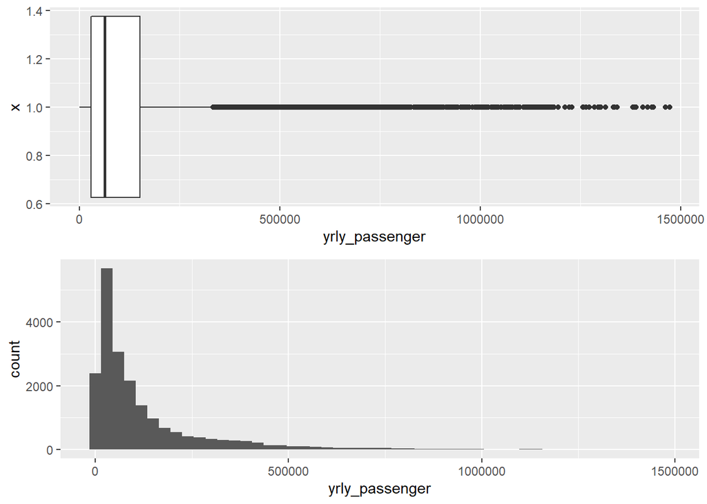

```r
grid.arrange(
  ggplot(data = yrly_com_flights_df, mapping = aes(x = 1, y = yrly_passenger)) +
    geom_boxplot() +
    coord_flip(),

  ggplot(data = yrly_com_flights_df, mapping = aes(x = yrly_passenger)) +
    geom_histogram(bins = 50),

  ncol = 1
)
```

### 2.2.4 Load Factor and Passenger Growth (last year)

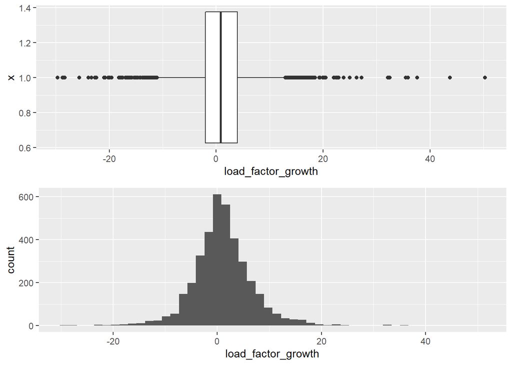

```r
grid.arrange(
  ggplot(data = filter(yrly_com_flights_df, year == 2009), mapping = aes(x = 1, y = load_factor_growth)) +
    geom_boxplot() +
    coord_flip(),

  ggplot(data = filter(yrly_com_flights_df, year == 2009), mapping = aes(x = load_factor_growth)) +
    geom_histogram(bins = 50),

  ncol = 1
)
```

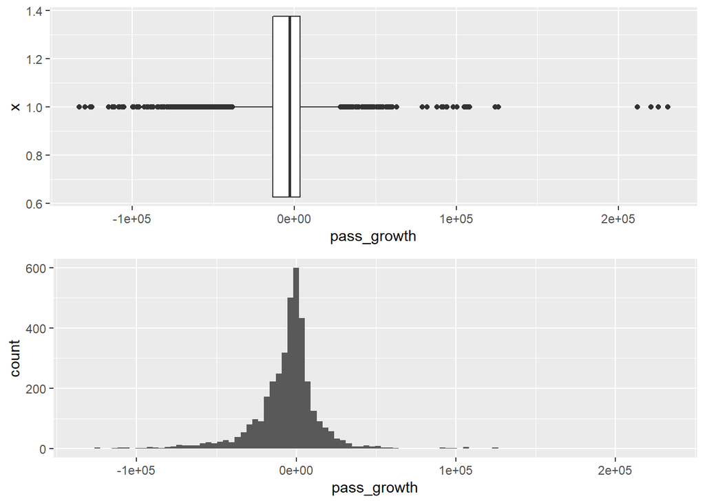

```r
grid.arrange(
  ggplot(data = filter(yrly_com_flights_df, year == 2009), mapping = aes(x = 1, y = pass_growth)) +
    geom_boxplot() +
    coord_flip(),

  ggplot(data = filter(yrly_com_flights_df, year == 2009), mapping = aes(x = pass_growth)) +
    geom_histogram(bins = 100),

  ncol = 1
)
```

- Growth relatively symmetrical distribution
- Median above zero, showing overall load factor growth
- Median below zero, showing overall negative passenger growth
- Interested to look at the large growth routes

# 3 Individual Route and City Analysis

## 3.1 Top Airports

- Looking at cities instead of departure airports to make analysis consistent for places with multiple airports

### 3.1.1 By Passenger Volume

```r
yrly_com_flights_df %>% group_by(origin_city) %>%
  summarize(total_passengers = sum(yrly_passenger)) %>%
  arrange(desc(total_passengers)) %>%
  head(10)
```

```
## # A tibble: 10 x 2
##    origin_city     total_passengers
##    <chr>                      <dbl>
##  1 Chicago, IL            167870652
##  2 Atlanta, GA            166352162
##  3 Dallas, TX             133585332
##  4 New York, NY           101262501
##  5 Los Angeles, CA         97178643
##  6 Houston, TX             90067116
##  7 Las Vegas, NV           89010391
##  8 Phoenix, AZ             85306855
##  9 Washington, DC          75226977
## 10 Orlando, FL             69094528
```

### 3.1.2 By Load Factor

```r
yrly_com_flights_df %>% group_by(origin_city) %>%
  summarize(total_load_factor = sum(yrly_passenger)/ sum(yrly_seats)) %>%
  arrange(desc(total_load_factor)) %>%
  head(10)
```

```
## # A tibble: 10 x 2
##    origin_city         total_load_factor
##    <chr>                           <dbl>
##  1 Plattsburgh, NY                 0.923
##  2 Rockford, IL                    0.839
##  3 Honolulu, HI                    0.809
##  4 Orlando, FL                     0.800
##  5 West Palm Beach, FL             0.800
##  6 Miami, FL                       0.799
##  7 Las Vegas, NV                   0.795
##  8 Manhattan, KS                   0.794
##  9 Stockton, CA                    0.794
## 10 Seattle, WA                     0.793
```

### 3.1.3 Five year passenger volume growth

```r
yrly_com_flights_df %>% group_by(origin_city) %>%
  summarize(total_passenger_growth = sum(pass_growth, na.rm = TRUE)) %>%
  arrange(desc(total_passenger_growth)) %>%
  head(10)
```

```
## # A tibble: 10 x 2
##    origin_city       total_passenger_growth
##    <chr>                              <dbl>
##  1 Charlotte, NC                    2316311
##  2 San Francisco, CA                1892477
##  3 Miami, FL                         443568
##  4 Milwaukee, WI                     442042
##  5 Seattle, WA                       422684
##  6 Baltimore, MD                     402047
##  7 Buffalo, NY                       168311
##  8 Austin, TX                        121433
##  9 Bellingham, WA                    120914
## 10 San Antonio, TX                   115523
```

### 3.1.4 Five year seat volume growth

```r
yrly_com_flights_df %>% group_by(origin_city) %>%
  summarize(total_seat_growth = sum(seat_growth, na.rm = TRUE)) %>%
  arrange(desc(total_seat_growth)) %>%
  head(10)
```

```
## # A tibble: 10 x 2
##    origin_city       total_seat_growth
##    <chr>                         <dbl>
##  1 San Francisco, CA           1772700
##  2 Milwaukee, WI                240721
##  3 Charlotte, NC                226965
##  4 Seattle, WA                  163172
##  5 Bellingham, WA               147002
##  6 Fayetteville, NC              96285
##  7 Buffalo, NY                   94365
##  8 Atlantic City, NJ             92817
##  9 Lafayette, LA                 65522
## 10 Killeen, TX                   57379
```

- Interesting Charlotte has largest passenger growth but is 3rd in seat growth
- *Does that imply a large load factor increase?*

```r
#take closer look at Charlotte
#EDIT:  Used this to identify duplicate ABE routes which greatly affected Charlotte numbers.  Fixed in wrangle section above
#yrly_com_flights_df %>% filter(origin_code == 'CLT')
```

### 3.1.5 Five year load factor growth

```r
#total five year load factor growth
yrly_com_flights_df %>% group_by(origin_city) %>%
  summarize(total_load_factor_growth = sum(load_factor_growth, na.rm = TRUE)) %>%
  arrange(desc(total_load_factor_growth)) %>%
  head(10)
```

```
## # A tibble: 10 x 2
##    origin_city        total_load_factor_growth
##    <chr>                                 <dbl>
##  1 Charlotte, NC                          990.
##  2 Atlanta, GA                            785.
##  3 Philadelphia, PA                       754.
##  4 Cincinnati, OH                         752.
##  5 Salt Lake City, UT                     631.
##  6 Las Vegas, NV                          548.
##  7 Baltimore, MD                          544.
##  8 Detroit, MI                            528.
##  9 Phoenix, AZ                            412.
## 10 Washington, DC                         409.
```

```r
#average growth per route
yrly_com_flights_df %>% group_by(origin_city) %>%
  summarize(n = n(), avg_load_factor_growth = sum(load_factor_growth, na.rm = TRUE) / n) %>%
  arrange(desc(avg_load_factor_growth)) %>%
  head(10)
```

```
## # A tibble: 10 x 3
##    origin_city        n avg_load_factor_growth
##    <chr>          <int>                  <dbl>
##  1 Altoona, PA        2                   8.97
##  2 Stockton, CA       4                   5.63
##  3 Decatur, IL        2                   5.33
##  4 Greenville, NC     5                   4.85
##  5 Butte, MT         11                   4.57
##  6 Staunton, VA       3                   4.32
##  7 Florence, SC      10                   4.04
##  8 Lynchburg, VA     10                   3.95
##  9 Elmira, NY        10                   3.87
## 10 Scranton, PA      33                   3.75
```

```r
#above top 10 is all very small routes (n < 33 over five years)
#check with n > 100 (20 routes/yr)
yrly_com_flights_df %>% group_by(origin_city) %>%
  summarize(n = n(), avg_load_factor_growth = sum(load_factor_growth, na.rm = TRUE) / n) %>%
  filter(n > 100) %>%
  arrange(desc(avg_load_factor_growth)) %>%
  head(10)
```

```
## # A tibble: 10 x 3
##    origin_city            n avg_load_factor_growth
##    <chr>              <int>                  <dbl>
##  1 Charlotte, NC        436                   2.27
##  2 Baltimore, MD        272                   2.00
##  3 Philadelphia, PA     381                   1.98
##  4 Providence, RI       112                   1.62
##  5 Cincinnati, OH       475                   1.58
##  6 Salt Lake City, UT   405                   1.56
##  7 Indianapolis, IN     177                   1.24
##  8 Las Vegas, NV        447                   1.23
##  9 Austin, TX           178                   1.21
## 10 Hartford, CT         153                   1.17
```

- **As expected from passenger/seat numbers, Charlotte has highest load factor growth**

## 3.2 City Growth Analysis

```r
#total five year pop growth
pop_increases %>% group_by(origin_city) %>%
  summarize(total_pop_growth = sum(pop_increase, na.rm = TRUE)) %>%
  arrange(desc(total_pop_growth))
```

```
## # A tibble: 275 x 2
##    origin_city       total_pop_growth
##    <chr>                        <dbl>
##  1 Dallas, TX                 1262416
##  2 Houston, TX                 567922
##  3 New York, NY                543364
##  4 Atlanta, GA                 528201
##  5 Washington, DC              493948
##  6 Phoenix, AZ                 479506
##  7 Chicago, IL                 436974
##  8 Seattle, WA                 410920
##  9 San Francisco, CA           336492
## 10 Newark, NJ                  271682
## # ... with 265 more rows
```

```r
#by percentage
pop_increases %>% group_by(origin_city) %>%
  summarize(min_year = min(year), percent_pop_growth = sum(pop_increase, na.rm = TRUE) / avg_pop[year == min_year] * 100) %>%
  arrange(desc(percent_pop_growth))
```

```
## # A tibble: 275 x 3
##    origin_city        min_year percent_pop_growth
##    <chr>                 <int>              <dbl>
##  1 Raleigh, NC            2005               18.1
##  2 Austin, TX             2005               16.4
##  3 St. George, UT         2005               15.4
##  4 Myrtle Beach, SC       2005               15.4
##  5 Charlotte, NC          2005               14.9
##  6 Grand Junction, CO     2005               12.9
##  7 Idaho Falls, ID        2005               12.8
##  8 Bend, OR               2005               12.5
##  9 Phoenix, AZ            2005               12.3
## 10 Fayetteville, AR       2005               12.3
## # ... with 265 more rows
```

- Austin and Charlotte are in top ten for load factor growth and percent population growth
- Total population growth and passenger growth also have cities in common
- Dallas has by far the largest population growth
- **Correlation between city growth and airport growth?**

# 4 Statistics

## 4.1 Check correlations

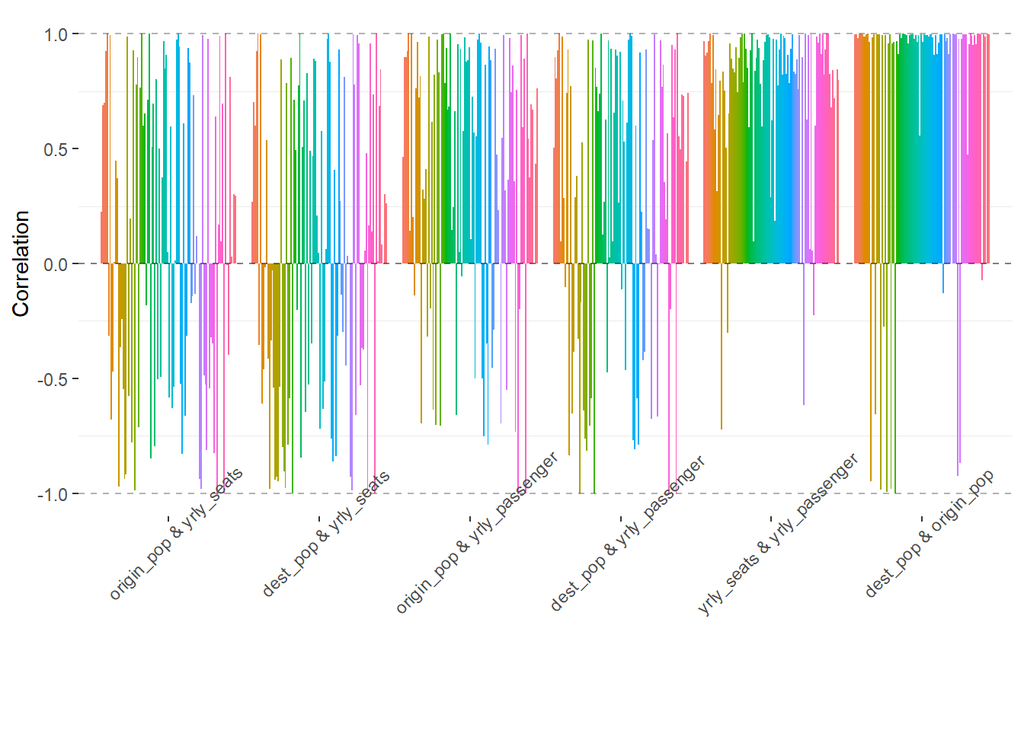

```r
#this plot doesn't look right.  maybe not the right format of df
# yrly_com_flights_df %>%
#   group_by(origin_city, year) %>%
#   select(yrly_passenger, yrly_seats, origin_pop, dest_pop) %>%
#   inspect_cor() %>%
#   show_plot()

#try on one city
yrly_com_flights_df %>%
  filter(origin_city == 'Charlotte, NC') %>%
  select(yrly_passenger, yrly_seats, origin_pop, dest_pop) %>%
  inspect_cor() %>%
  show_plot()
```

- Still not a fan of above method from week 10. Do manual testing instead

### 4.1.1 Population and Passengers

```r
#First group flights by city so individual routes aren't being tested
#combine all the above parameters into this dataset
yrly_com_flights_by_city <- yrly_com_flights_df %>%
  group_by(origin_city) %>%
  summarize(total_passengers = sum(yrly_passenger),
            total_seats = sum(yrly_seats),
            total_load_factor = sum(yrly_passenger)/ sum(yrly_seats),
            total_passenger_growth = sum(pass_growth, na.rm = TRUE),
            passenger_growth_percentage = total_passenger_growth / total_passengers * 100,
            total_seat_growth = sum(seat_growth, na.rm = TRUE),
            total_load_factor_growth = sum(load_factor_growth, na.rm = TRUE),
            n = n(),
            avg_load_factor_growth = sum(load_factor_growth, na.rm = TRUE) / n)

#add pop data and join
pop_increases_by_city <- pop_increases %>%
  group_by(origin_city) %>%
  summarize(total_pop_growth = sum(pop_increase, na.rm = TRUE),
            min_year = min(year),
            percent_pop_growth = sum(pop_increase, na.rm = TRUE) / avg_pop[year == min_year] * 100,
            avg_pop = mean(avg_pop))#keep population in df. 5yr avg in this case

#join
yrly_com_flights_by_city <- inner_join(yrly_com_flights_by_city, pop_increases_by_city, by = 'origin_city') %>%
  select(-min_year) %>%
  filter(n > 50) # also filter out very small cities (less than 10 routes/yr)

#save for potential use on dash
write_csv(yrly_com_flights_by_city, path = 'yrly_com_flights_by_city.csv')
```

```r
cor.test(yrly_com_flights_by_city$total_passengers, yrly_com_flights_by_city$avg_pop,
         method = 'pearson')
```

```
##
##  Pearson's product-moment correlation
##
## data:  yrly_com_flights_by_city$total_passengers and yrly_com_flights_by_city$avg_pop
## t = 7.5979, df = 81, p-value = 4.63e-11
## alternative hypothesis: true correlation is not equal to 0
## 95 percent confidence interval:
##  0.4987889 0.7556318
## sample estimates:
##       cor
## 0.6450785
```

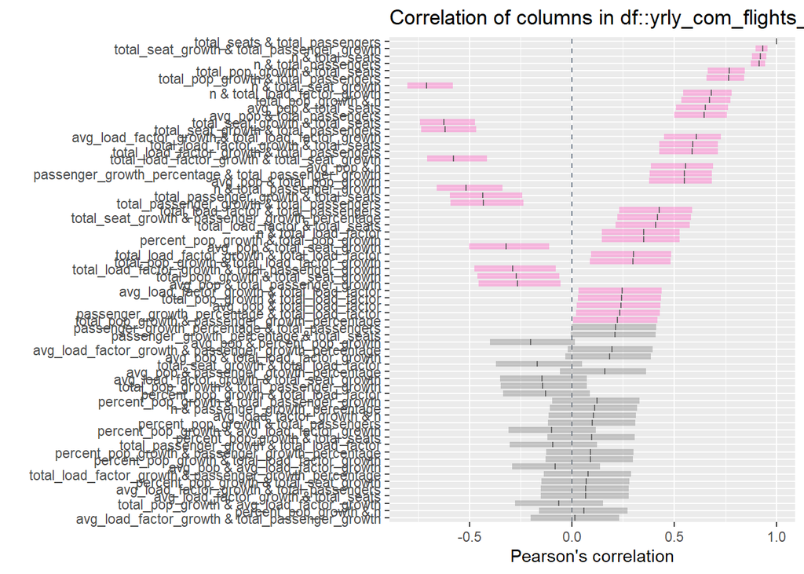

```r
#test inspect_cor again with grouped df
yrly_com_flights_by_city %>%
  inspect_cor() %>%
  show_plot()
```

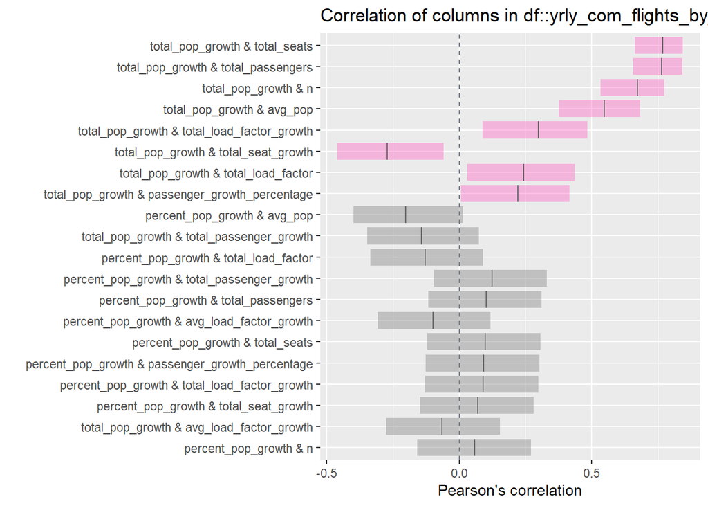

```r
#narrow down for easier reading
yrly_com_flights_by_city %>%
  inspect_cor(with_col = c('total_pop_growth', 'percent_pop_growth')) %>%
  show_plot()
```

- High correlation between total population growth and total passengers
- Not quite as high but still significant correlation between population growth and load factor growth
- Interesting negative correlation between population growth and seat growth

**Want to identify cities with:** - Population growth (correlated to passenger and load factor growth) - High load factors (room for more seats as higher percentage is filled)

## 4.2 Test significance of top cities from rankings above

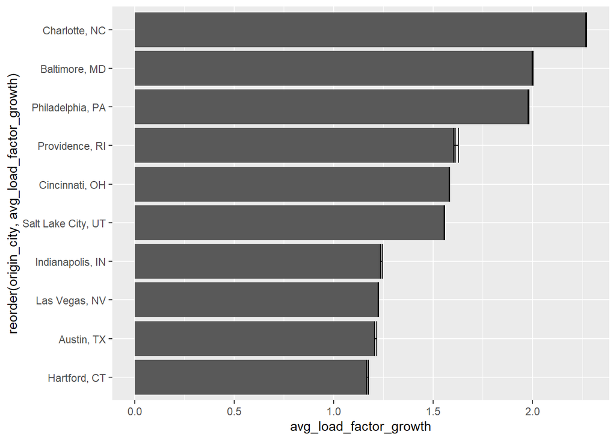

```r
z <- qnorm(0.975)

yrly_com_flights_df %>% group_by(origin_city) %>%
  summarize(n = n(),
            avg_load_factor_growth = sum(load_factor_growth, na.rm = TRUE) / n,
            sd = sd(load_factor_growth , na.rm = TRUE) / n,
            ci = z*sd / sqrt(n)) %>%
  filter(n > 100) %>%
  arrange(desc(avg_load_factor_growth)) %>%
  head(10) %>%
  ggplot(mapping = aes(x = reorder(origin_city, avg_load_factor_growth), y = avg_load_factor_growth)) +
  geom_bar(stat = 'identity') +
  geom_errorbar(aes(ymin = avg_load_factor_growth - ci, ymax = avg_load_factor_growth + ci)) +
  coord_flip()
```

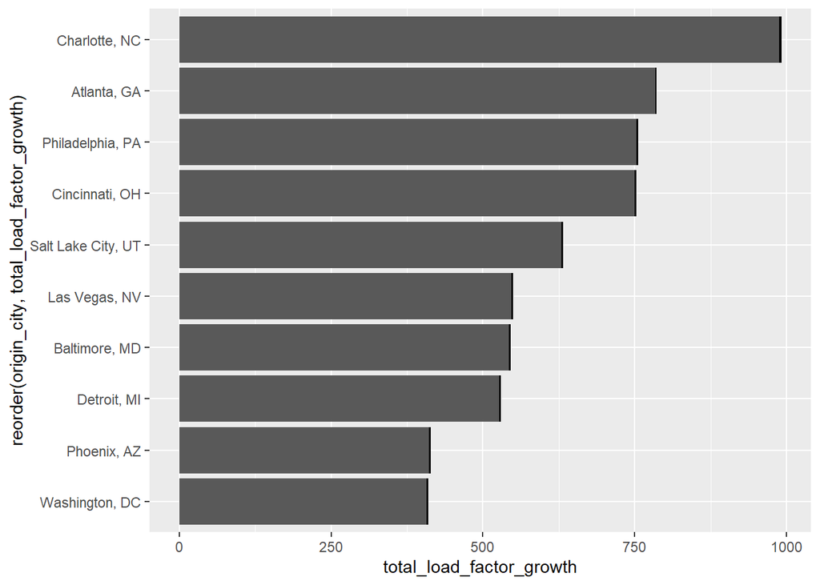

```r
z <- qnorm(0.975)

yrly_com_flights_df %>% group_by(origin_city) %>%
  summarize(n = n(),
            total_load_factor_growth = sum(load_factor_growth, na.rm = TRUE) ,
            sd = sd(load_factor_growth, na.rm = TRUE),
            ci = z*sd / sqrt(n)) %>%
  filter(n > 100) %>%
  arrange(desc(total_load_factor_growth)) %>%
  head(10) %>%
  ggplot(mapping = aes(x = reorder(origin_city, total_load_factor_growth), y = total_load_factor_growth)) +
  geom_bar(stat = 'identity') +
  geom_errorbar(aes(ymin = total_load_factor_growth - ci, ymax = total_load_factor_growth + ci)) +
  coord_flip()
```

Charlotte had significantly higher load factor growth than other cities

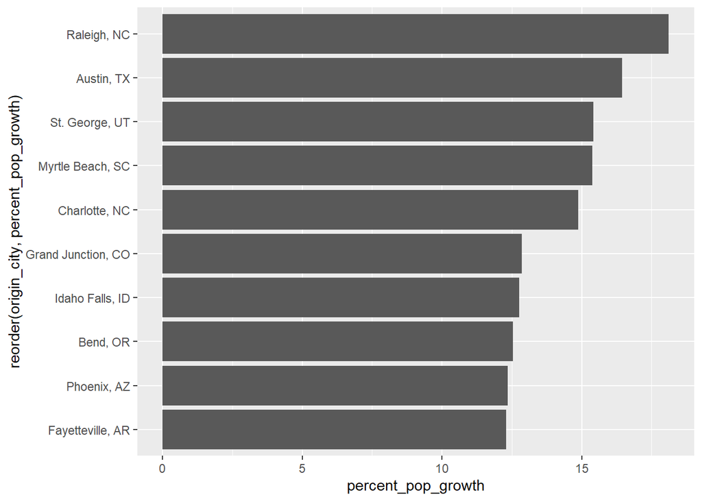

```r
pop_increases %>% group_by(origin_city) %>%
  summarize(min_year = min(year), percent_pop_growth = sum(pop_increase, na.rm = TRUE) / avg_pop[year == min_year] * 100) %>%
  arrange(desc(percent_pop_growth)) %>%
  head(10) %>%
  ggplot(mapping = aes(x = reorder(origin_city, percent_pop_growth), y = percent_pop_growth)) +
  geom_bar(stat = 'identity') +
  coord_flip()
```

## 4.3 Look at plots of correlated vars

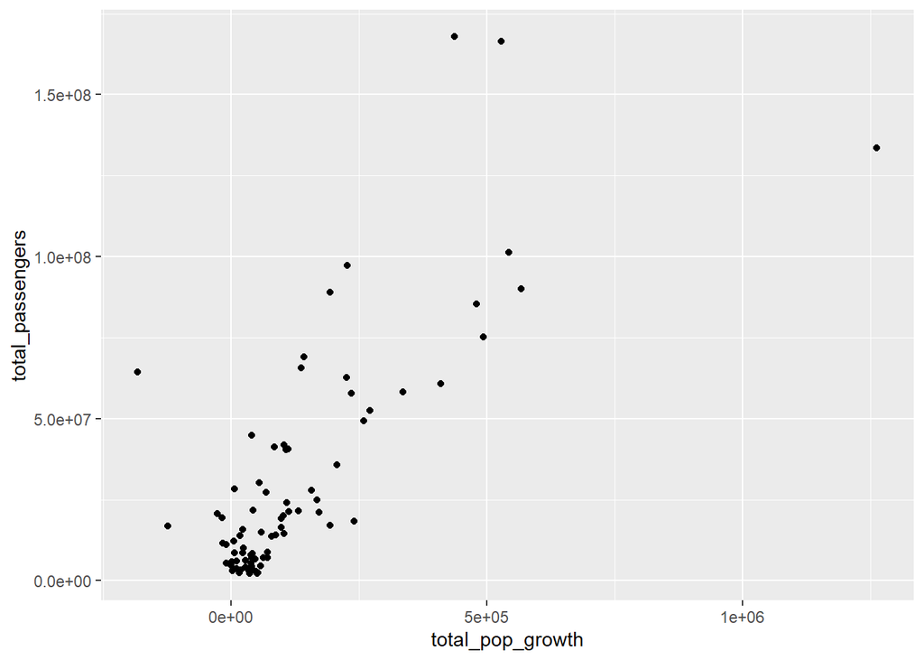

```r
#all points to show trend
yrly_com_flights_by_city %>%
  ggplot(mapping = aes(x = total_pop_growth, y = total_passengers, label = origin_city)) +
  geom_point()
```

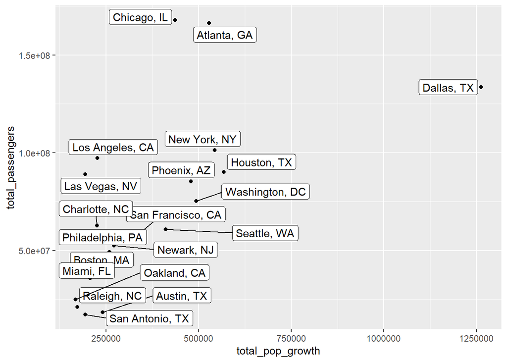

```r
#top 20 by poulation growth
yrly_com_flights_by_city %>%
  arrange(desc(total_pop_growth)) %>%
  head(20) %>%
  ggplot(mapping = aes(x = total_pop_growth, y = total_passengers, label = origin_city)) +
  geom_point() +
  geom_label_repel()
```

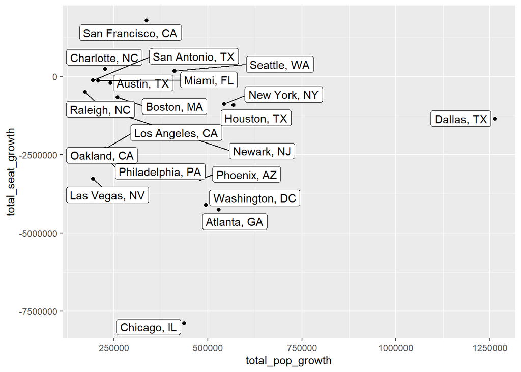

```r
yrly_com_flights_by_city %>%
  arrange(desc(total_pop_growth)) %>%
  head(20) %>%
  ggplot(mapping = aes(x = total_pop_growth, y = total_seat_growth, label = origin_city)) +
  geom_point() +
  geom_label_repel()
```

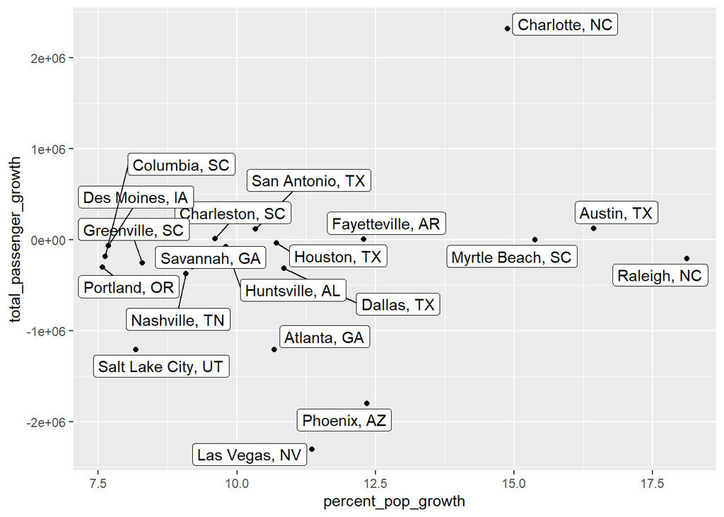

```r
yrly_com_flights_by_city %>%
  arrange(desc(percent_pop_growth)) %>%
  head(20) %>%
  ggplot(mapping = aes(x = percent_pop_growth, y = total_passenger_growth, label = origin_city)) +
  geom_point() +
  geom_label_repel()
```

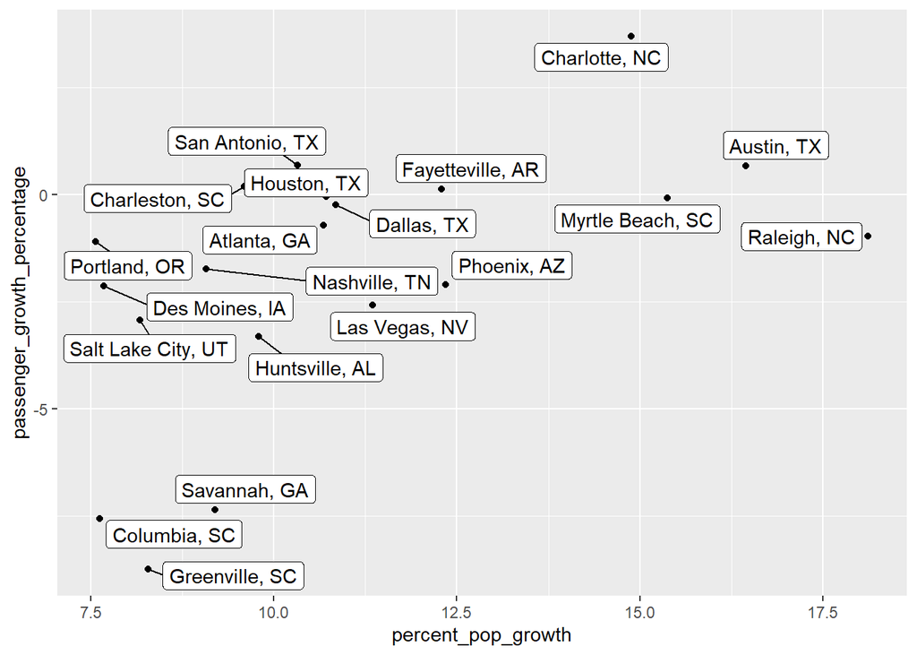

```r
yrly_com_flights_by_city %>%
  arrange(desc(percent_pop_growth)) %>%
  head(20) %>%
  ggplot(mapping = aes(x = percent_pop_growth, y = passenger_growth_percentage, label = origin_city)) +
  geom_point() +
  geom_label_repel()
```

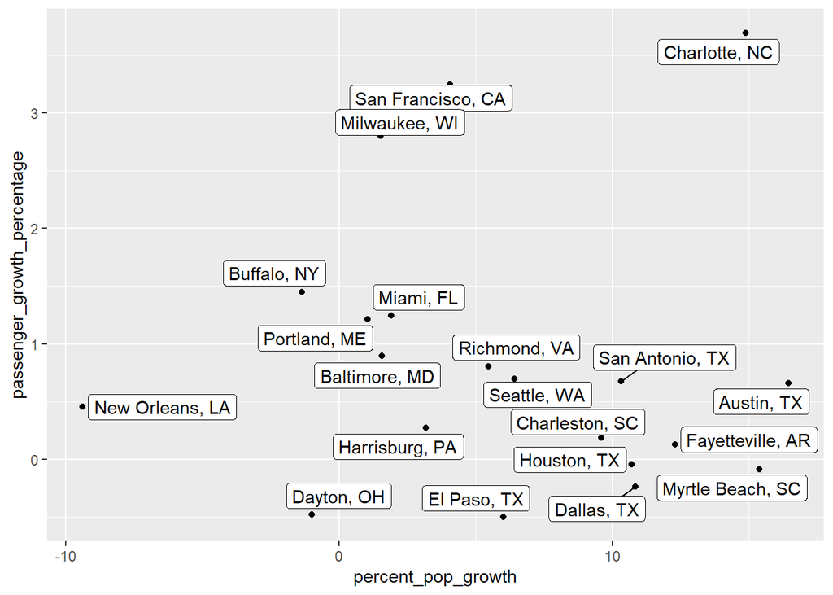

```r
yrly_com_flights_by_city %>%
  arrange(desc(passenger_growth_percentage)) %>%
  head(20) %>%
  ggplot(mapping = aes(x = percent_pop_growth, y = passenger_growth_percentage, label = origin_city)) +
  geom_point() +
  geom_label_repel()
```

- Remember, overall passenger volumes are down so Austin and Charlotte are outliers for growing

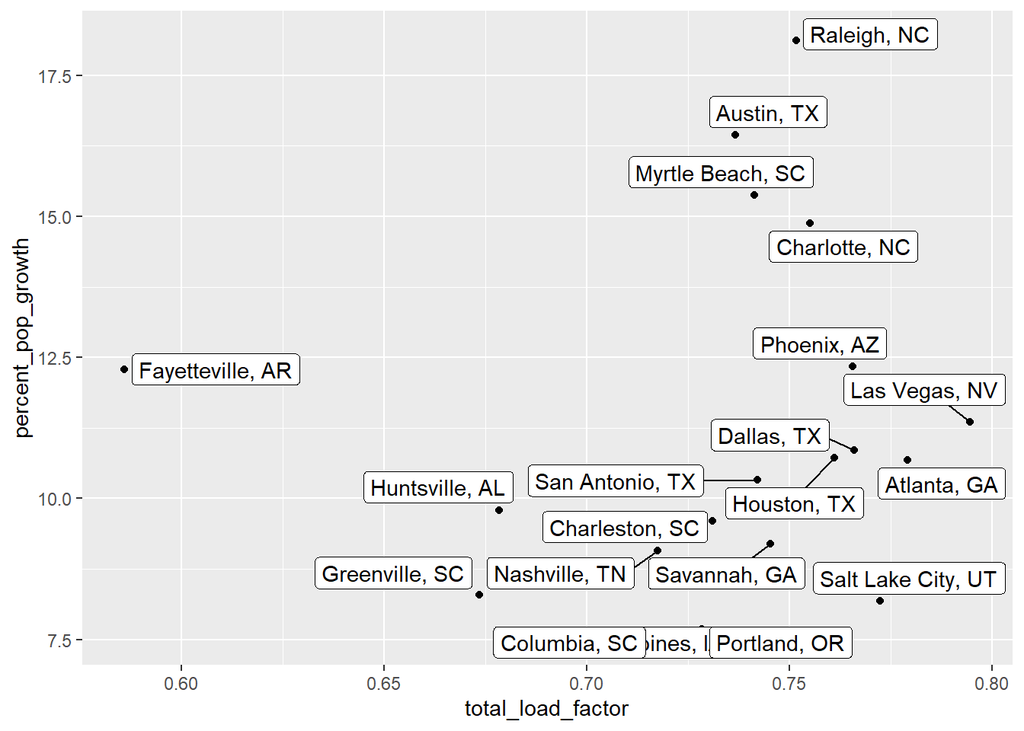

```r
yrly_com_flights_by_city %>%
  arrange(desc(percent_pop_growth)) %>%
  head(20) %>%
  ggplot(mapping = aes(x = total_load_factor, y = percent_pop_growth, label = origin_city)) +
  geom_point() +
  geom_label_repel()
```

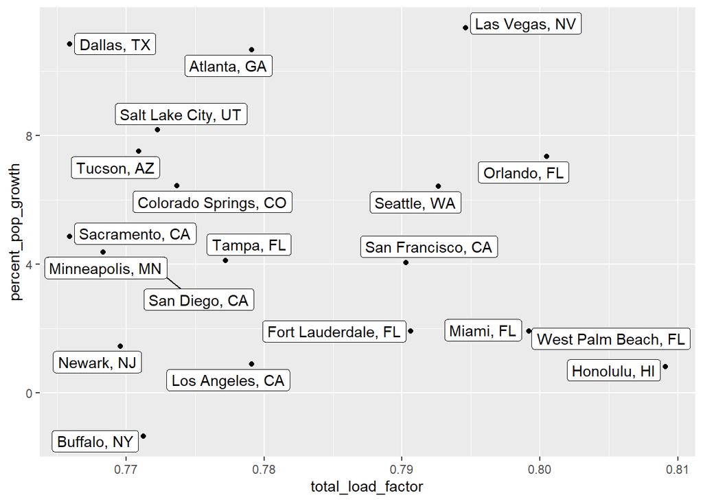

```r
yrly_com_flights_by_city %>%
  arrange(desc(total_load_factor)) %>%
  head(20) %>%
  ggplot(mapping = aes(x = total_load_factor, y = percent_pop_growth, label = origin_city)) +
  geom_point() +
  geom_label_repel()
```

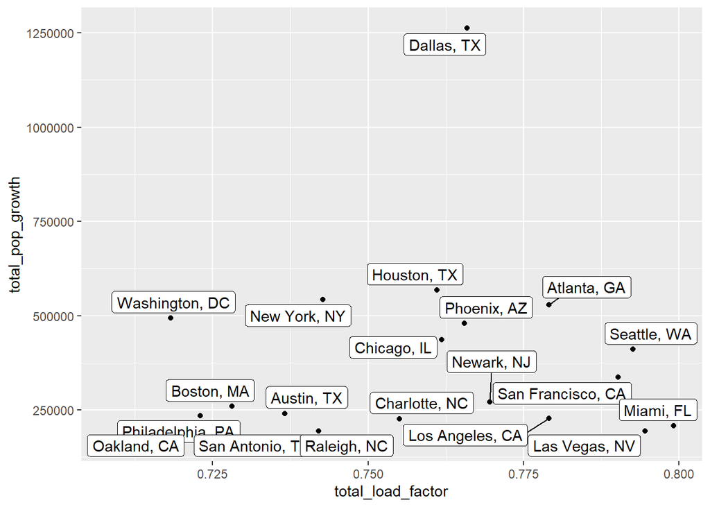

```r
yrly_com_flights_by_city %>%
  arrange(desc(total_pop_growth)) %>%
  head(20) %>%
  ggplot(mapping = aes(x = total_load_factor, y = total_pop_growth, label = origin_city)) +
  geom_point() +
  geom_label_repel()
```

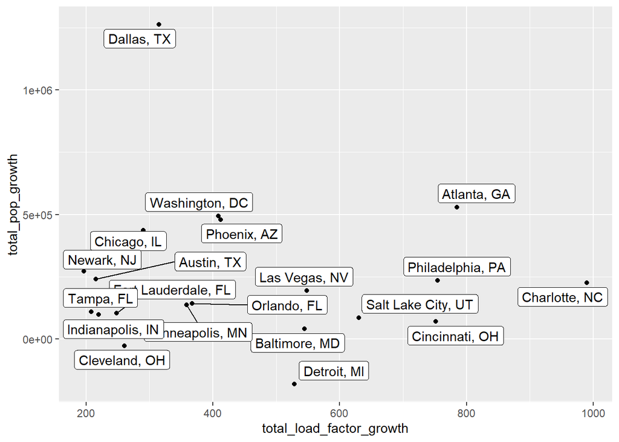

```r
#load factor growths
yrly_com_flights_by_city %>%
  arrange(desc(total_load_factor_growth)) %>%
  head(20) %>%
  ggplot(mapping = aes(x = total_load_factor_growth, y = total_pop_growth, label = origin_city)) +
  geom_point() +
  geom_label_repel()
```